# Project 2

## Clustering

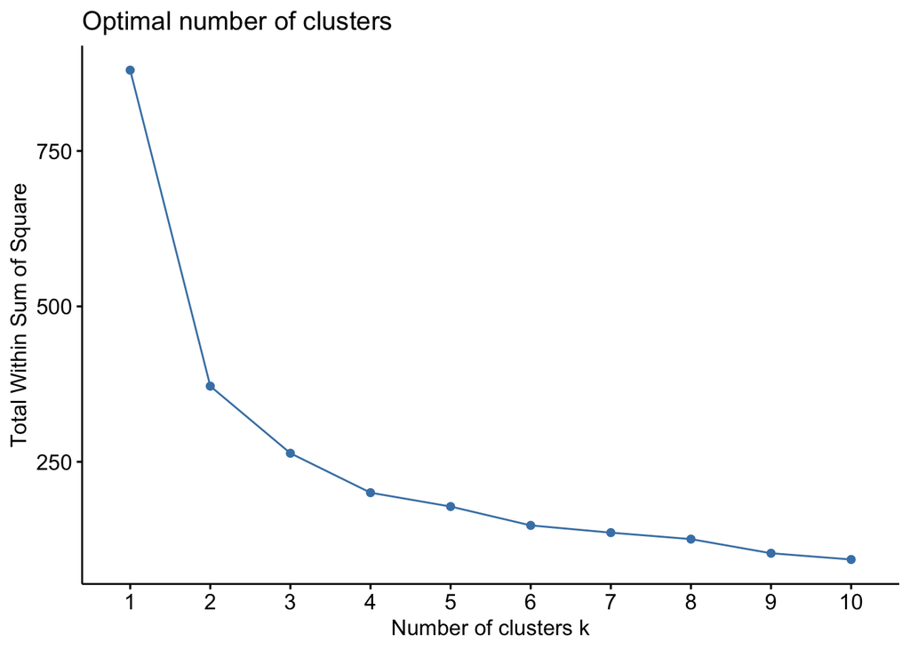

```r
# STEP 1: choose number of clusters

# select variables, scale, and create new dataframe
cia_var <- cia_clean %>%
  select(-country_type, -country, -area, -internet_users, -net_migration_rate, -population, -population_growth_rate) %>%
  scale

# find optimal number of clusters using within sum-of-squares (wss) method
# minimize WSS while keeping a small number of clusters
fviz_nbclust(cia_var, pam, method = "wss")
```

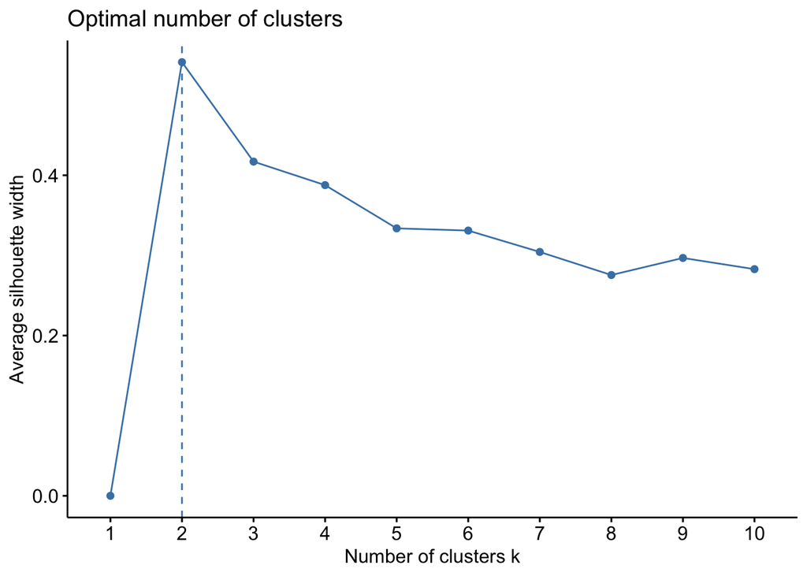

```r
# find optimal number of clusters using silhouette method
# check silhouette width
fviz_nbclust(cia_var, pam, method = "silhouette")
```

After finding our variables of interest, the next step in our project was to cluster our data. To do that, we searched for the best number of clusters. Using the WSS method (which measures the “compactness” of the clustering and minimizes it), it seems that the optimal number of clusters for the PAM method is around 2 or 3. We then implemented the silhouette method (which measures the quality of a clustering and determines how well each object lies within its cluster by considering both the WSS and the between-sum-of-squares), determining that the optimal number of clusters was indeed 2. Having found a number of clusters, we then moved on to clustering the data using the PAM method.

# PAM Clustering

```r
# STEP 2: Use PAM method for clustering select variables (life expectancy, birth rate, death rate, maternal mortality rate, infant mortality rate)

# apply a clustering algorithm
pam_results <- cia_var %>%
  pam(k = 2)

# save cluster assignment as a column in dataset
cia_pam <- cia_clean %>%
  mutate(cluster = as.factor(pam_results$clustering))
```

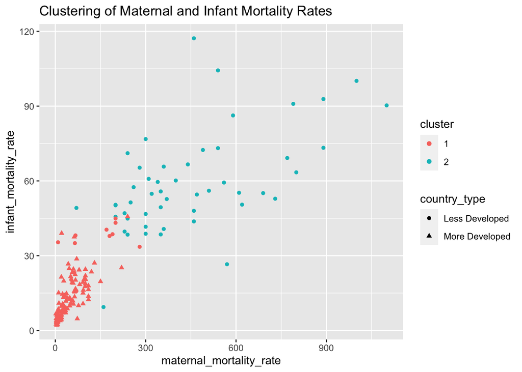

```r
# STEP 3: visualize clusters
# make a plot of data colored by final cluster assignment (infant vs maternal mortality rates)
cia_pam %>%
  ggplot(aes(maternal_mortality_rate, infant_mortality_rate, color = cluster)) +
  geom_point(aes(shape = country_type)) +
  labs(title="Clustering of Maternal and Infant Mortality Rates")
```

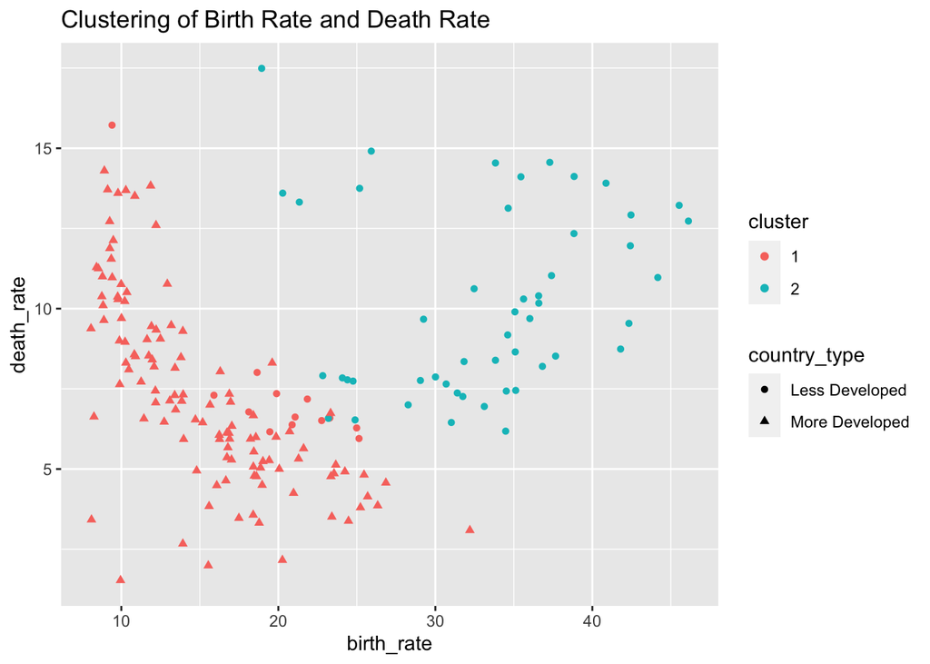

```r
# make a plot of data colored by final cluster assignment (death rate vs birth rate)
cia_pam %>%
  ggplot(aes(birth_rate, death_rate, color = cluster)) +
  geom_point(aes(shape = country_type)) +
  labs(title="Clustering of Birth Rate and Death Rate")
```

Once we had clustered the data into 2 clusters, we then created two plots, one displaying the relationship between maternal mortality and infant mortality and the other displaying birth rate vs death rate. In each plot, data points are shaped by country_type and colored by cluster. When viewing the scatter plots for infant vs maternal mortality rates, the clustering looks pretty accurate in that it clusters more developed countries into cluster 1 and less developed countries into cluster 2. This pattern with the clustering is also evident in the scatter plot for death rate vs birth rate. Some countries were less developed in cluster 1 but they mainly existed on the border between clusters. This was an exciting observation as it displays how the two clusters represent developed and underdeveloped nations.

```r
# STEP 4: evaluate clustering by calculating accuracy from cluster and country type
# compare the cluster and species
table(cia_pam$cluster, cia_pam$country_type)
```

```
##
##     Less Developed More Developed
##   1             13            114
##   2             50              0
```

```r
# calculate percentage of accuracy
(47+42+83/177)
```

```
## [1] 89.46893
```

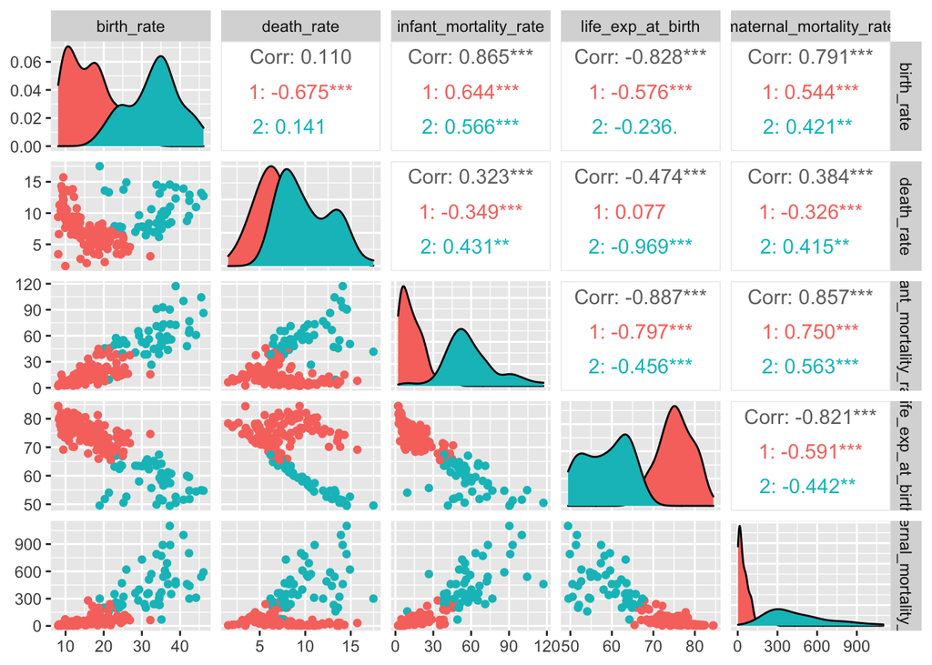

```r
# STEP 5.1: interpret clustering by visualizing clusters by showing pairwise combinations of variables

# show all pairwise combinations of variables colored by cluster assignment using ggpairs
ggpairs(cia_pam, columns = c(3,4,5,7,8), aes(color = cluster))
```

```r
# STEP 5.2: interpret clustering by creating summary statistic for each variable

# find means of each variable for each cluster
cia_pam %>%
  group_by(cluster) %>%
  summarise_at(c("birth_rate", "death_rate", "infant_mortality_rate", "life_exp_at_birth", "maternal_mortality_rate"), mean, na.rm = T)
```

```
## # A tibble: 2 × 6
##   cluster birth_rate death_rate infant_mortality_rate life_exp_at_birth
##   <fct>        <dbl>      <dbl>                 <dbl>             <dbl>
## 1 1             15.6       7.32                  14.3              75.4
## 2 2             33.2      10.1                   59.3              58.6
## # … with 1 more variable: maternal_mortality_rate <dbl>
```

Upon interpreting the clusters created using the PAM method, one can see that the countries clustered in cluster 1 are mostly those determined to be More Developed based on life expectancy at birth. Similarly, the countries in cluster 2 are mostly those in the Less Developed category. Looking at the summary statistics for each variable and the ggpairs scatterplot matrix, one can see that the average values for each variable is very different for each cluster. This is expected, as developed countries tend to have lower birth rates, death rates, and mortality rates, but higher life expectancy and vice versa for developing countries. For example, the average life expectancy at birth for countries in cluster 1 is around 75.38 while the average for countries in cluster 2 is around 58.64. The density plots in the ggpairs matrix show this trend, as countries in cluster 1 (indicated in red) tend to have life expectancy at birth higher than the median, while countries in cluster 2 (indicated in blue) have life expectancies less than the median. This divide is also evident for birth rate, as the density plots for each cluster are on either side of the median. The cluster 1 plot is left-skewed, meaning it has lower average birth rates than the median, while the cluster 2 plot is right-skewed, meaning it has higher average birth rates than the median. This trend is also true, in the sense that cluster 2 is more right-skewed than cluster 1, for death rate and infant and maternal mortality rates. The variables that showed strong negative or positive correlations with each other also showed those trends in the scatter plots and correlation coefficients in the ggpairs matrix. For next steps, it could be interesting to view the clustering when 3 clusters are created.

# K-Means Clustering

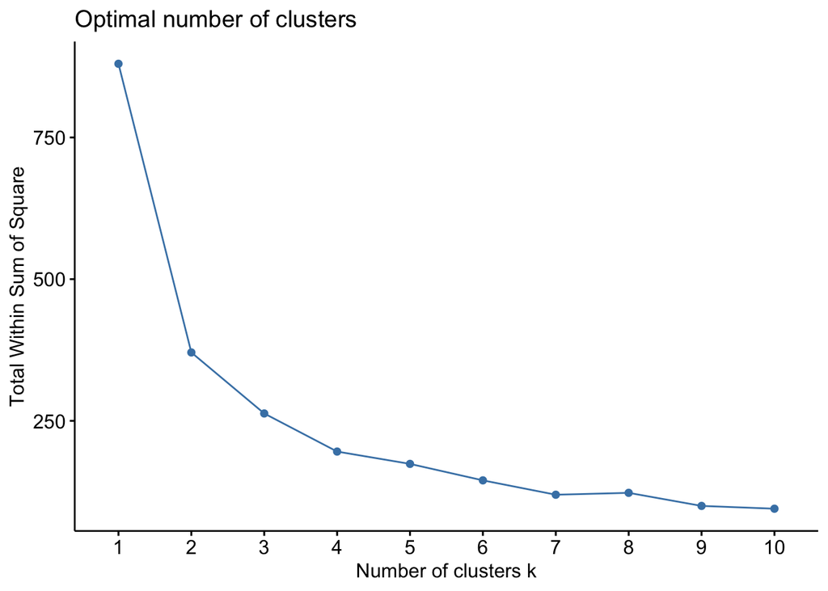

```r
# STEP 1: choose number of clusters

# find optimal number of clusters using within sum-of-squares (wss) method
# minimize WSS while keeping a small number of clusters
fviz_nbclust(cia_var, kmeans, method = "wss")
```

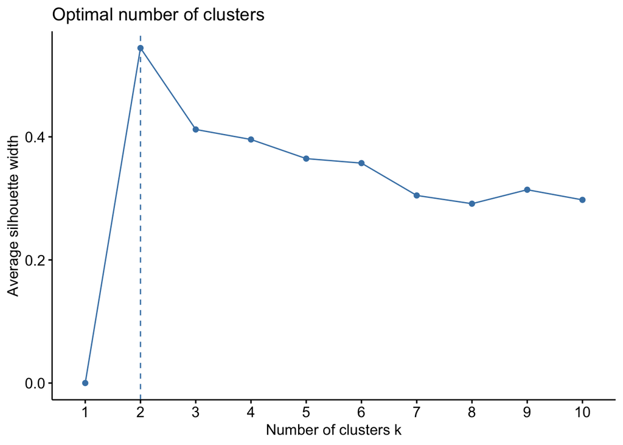

```r
# find optimal number of clusters using silhouette method
# check silhouette width
fviz_nbclust(cia_var, kmeans, method = "silhouette")
```

Using the WSS method, it seems that the optimal number of clusters for the kmeans method is around 2 or 3. Using the silhouette method, it is determined that the optimal number of clusters is 2.

```r
# STEP 2: Use kmeans to cluster selected variables

# use kmeans function to find 2 clusters
kmeans_results <- kmeans(na.omit(cia_var),2)

# show available components
names(kmeans_results)
```

```
## [1] "cluster"      "centers"      "totss"        "withinss"     "tot.withinss"
## [6] "betweenss"    "size"         "iter"         "ifault"
```

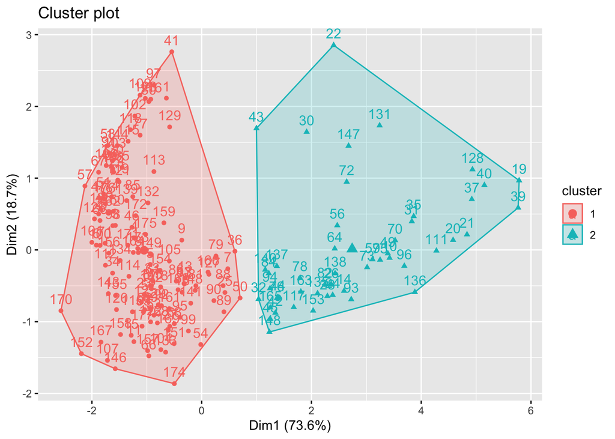

```r
# visualize data by final cluster assignment
fviz_cluster(kmeans_results, data = cia_var)
```

```r
# save cluster assignment as a column in dataset
cia_kmeans <- cia_clean %>%
  mutate(cluster = as.factor(kmeans_results$cluster))
```

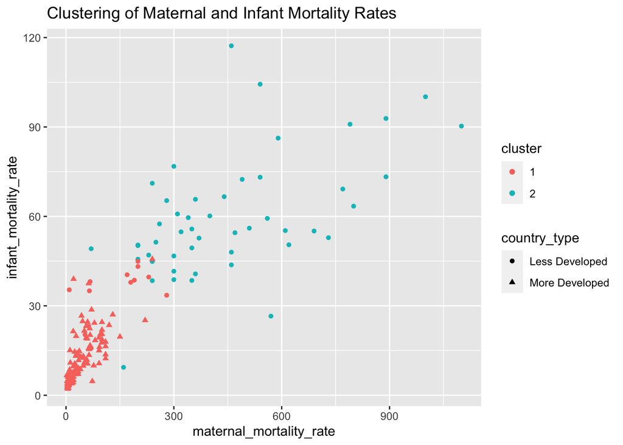

```r
# STEP 3: visualize clusters

# visualize data by final cluster assignment (death rate vs birth rate)
cia_kmeans %>%
  ggplot(aes(maternal_mortality_rate, infant_mortality_rate, color = cluster)) +
  geom_point(aes(shape = country_type)) +
  labs(title="Clustering of Maternal and Infant Mortality Rates")
```

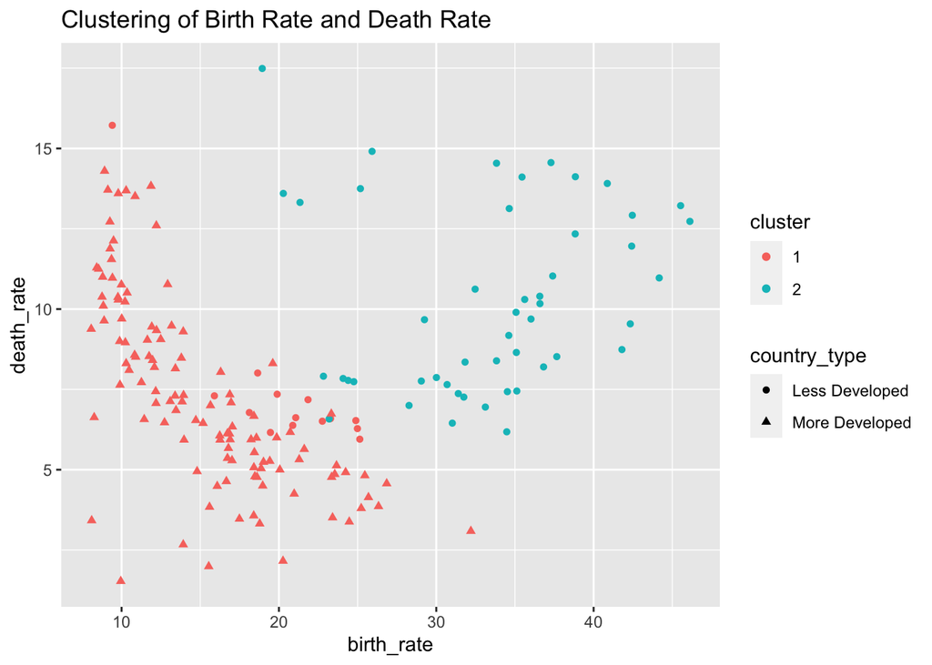

```r
# visualize data by final cluster assignment (infant vs maternal mortality rates)
cia_kmeans %>%
  ggplot(aes(birth_rate, death_rate, color = cluster)) +
  geom_point(aes(shape = country_type)) +
  labs(title="Clustering of Birth Rate and Death Rate")
```

```r
# STEP 4: evaluate clustering by calculating accuracy from cluster and country type

# compare the cluster and country type
table(cia_kmeans$cluster, cia_kmeans$country_type)
```

```
##
##     Less Developed More Developed
##   1             14            114
##   2             49              0
```

```r
# calculate percentage of accuracy
(47+43+83/177)
```

```
## [1] 90.46893
```

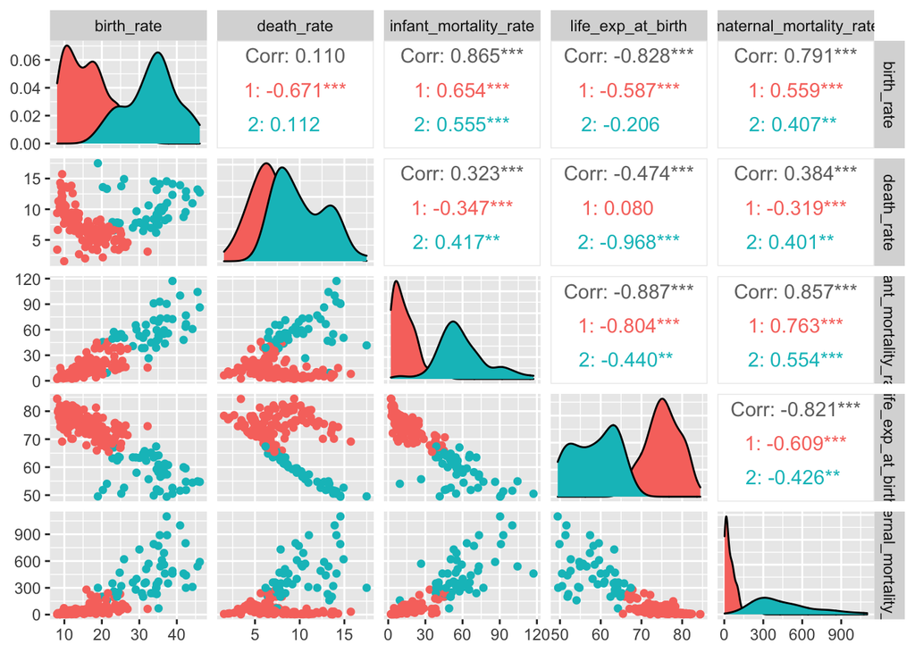

```r
# STEP 5.1: interpret clustering by visualizing clusters by showing pairwise combinations of variables

# show all pairwise combinations of variables colored by cluster assignment using ggpairs
ggpairs(cia_kmeans, columns = c(3,4,5,7,8), aes(color = cluster))
```

```r
# STEP 5.2: interpret clustering by creating summary statistic for each variable

# find means of each variable for each cluster
cia_kmeans %>%
  group_by(cluster) %>%
  summarise_at(c("birth_rate", "death_rate", "infant_mortality_rate", "life_exp_at_birth", "maternal_mortality_rate"), mean, na.rm = T)
```

```
## # A tibble: 2 × 6
##   cluster birth_rate death_rate infant_mortality_rate life_exp_at_birth
##   <fct>        <dbl>      <dbl>                 <dbl>             <dbl>
## 1 1             15.7       7.31                  14.5              75.3
## 2 2             33.3      10.2                   59.7              58.5
## # … with 1 more variable: maternal_mortality_rate <dbl>
```

## 4. Dimensionality Reduction

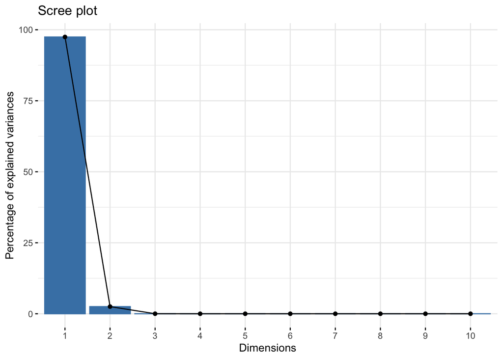

```r
library(factoextra)
# we use all numeric variables
pca <- cia_num %>%
  # use prcomp to find the principal components
  prcomp()
# percent of variances explained! choose how many pcs to retain
fviz_eig(pca)
```

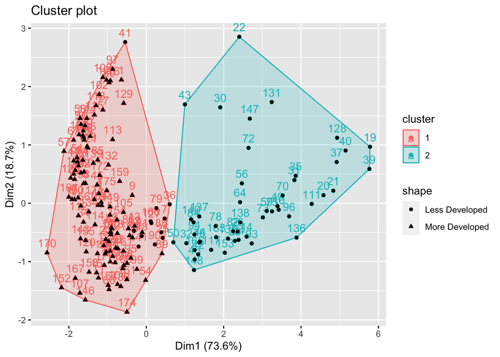

```r
# get the coefficients/loadings of each variable for each principal component (or dimension)
pca_df <- get_pca_var(pca)$coord %>% as.data.frame
# use fviz_cluster to to visualize the observations using the first two pcs
fviz_cluster(pam_results, data = cia_clean, shape = cia_clean$country_type) +
  geom_point(aes(shape = cia_clean$country_type)) +
  guides(shape = guide_legend(title = "shape"))
```

```r
pam_results
```

```
## Medoids:
##       ID birth_rate death_rate infant_mortality_rate life_exp_at_birth
## [1,] 173 -0.6882518 -0.3156842            -0.5647079         0.4773806
## [2,]  82  1.4830264  0.1701950             1.0452221        -1.1006654
##      maternal_mortality_rate
## [1,]              -0.5228299
## [2,]               0.9250185
## Clustering vector:
##   [1] 1 1 1 1 1 1 1 1 1 2 1 1 1 2 1 1 1 1 2 2 2 2 1 2 1 2 1 2 1 2 2 2 1 1 2 1 2
##  [38] 1 2 2 1 2 2 2 2 1 1 1 2 2 1 1 1 1 1 2 1 1 2 1 1 1 1 2 1 1 1 1 1 2 1 2 2 1
##  [75] 2 2 1 2 1 1 1 2 1 2 1 1 1 1 1 1 1 1 2 2 1 2 1 1 1 1 1 1 1 1 1 1 1 1 1 1 2
## [112] 1 1 1 1 1 2 1 1 1 1 1 1 1 1 1 1 2 1 1 2 1 1 1 2 2 2 2 1 2 1 1 1 1 1 1 2 2
## [149] 1 1 1 1 2 1 1 1 1 1 1 1 1 1 2 1 2 1 1 1 1 1 1 1 1 1 1 1 1
## Objective function:
##    build     swap
## 1.368294 1.326185
##
## Available components:
##  [1] "medoids"    "id.med"     "clustering" "objective"  "isolation"
##  [6] "clusinfo"   "silinfo"    "diss"       "call"       "data"
```

## Classification and Cross-Validation

```r
# KNN

# Step 1: Prepare Dataset for training
library(caret)
```

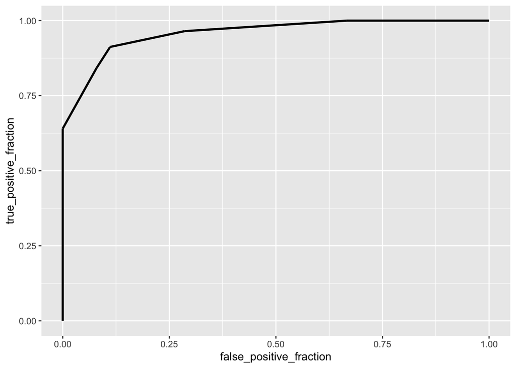

```r
library(plotROC)
cia_clean <- cia_clean %>% mutate(country_type = ifelse(country_type == 'Less Developed', 0, 1))

# Step 1: Train the Model
knn_fit <- knn3(factor(country_type == 1,
                       levels = c("TRUE","FALSE")) ~ birth_rate + death_rate + infant_mortality_rate + internet_users + life_exp_at_birth + maternal_mortality_rate + net_migration_rate + population + population_growth_rate,
                data = cia_clean,
                k = 5)

kNN_cia <- cia_clean %>%
  mutate(proportion = predict(knn_fit, cia_clean)[,1])

# Step 2: Build ROC curve
ROC <- kNN_cia %>% ggplot() +
  geom_roc(aes(d = country_type, m = proportion), n.cuts = 0)
ROC
```

```r
# calculate ROC
calc_auc(ROC)
```

```
##   PANEL group       AUC
## 1     1    -1 0.9581593
```

After training our classifier model and testing it on the whole dataset, we received an AUC of %95.81. This was a great accuracy as it was close to perfect. Our model accuracy was not surprising as all of our previous graphs displayed each Less and More developed nations in close proximity.

```r
# Step 3: Perform k-fold Cross-Validation
set.seed(322)

# your code goes below this line (make sure to edit comment)
k = 10

# Randomly order rows in the dataset
data <- cia_clean[sample(nrow(cia_clean)), ]

# Create k folds from the dataset
folds <- cut(seq(1:nrow(data)), breaks = k, labels = FALSE)

# Use a for loop to get diagnostics for each test set
diags_k <- NULL

for(i in 1:k){
  # Create training and test sets
  train <- data[folds != i, ] # all observations except in fold i
  test <- data[folds == i, ]  # observations in fold i

  # Train model on training set (all but fold i)
  knn_fit <- knn3(factor(country_type == 1,
                       levels = c("TRUE","FALSE")) ~ birth_rate + death_rate + infant_mortality_rate + internet_users + life_exp_at_birth + maternal_mortality_rate + net_migration_rate + population + population_growth_rate,
                data = train,
                k = 5)

  kNN_cia <- test %>%
    mutate(proportion = predict(knn_fit, test)[,1])

  # Step 2: Build ROC curve
  ROC <- kNN_cia %>% ggplot() +
    geom_roc(aes(d = country_type, m = proportion), n.cuts = 0)
  ROC
  calc_auc(ROC)

  # Get diagnostics for fold i (AUC)
  diags_k[i] <- calc_auc(ROC)$AUC
}
mean(diags_k)
```

```
## [1] 0.883212
```

Though model accuracy was satisfactory, we wanted to also ensure that our KNN classifier could effectively applied to potential nations not in our data or new data in later years. In order to verify this, we performed a 10-fold cross validation, choosing different portions of data to train and test in each fold. At the end of each fold, we saved the AUC. The final mean performance was calculated by averaging these AUC values across all the folds. Mean performance came out to %88.32. While this was still good, it was slightly worse than the original AUC calculated. This indicates that our model is likely over-fitting to the training data and cannot classify new observations as well as previously trained observations. Nevertheless, our overall accuracy was still very good and it proves the interconnected nature of life expectancy and all other variables.

Overall, it was highly informative to analyze, cluster, and classify the CIA Factbook dataset. While no country is the same, it seems humanity as a whole follows similar trends as we develop and modernize.

## Formatting.

Create the report using R Markdown, with headers for each section; include comments to the R code; include references (datasets, context). The final report is less than 20 pages. If working in a group, acknowledge how each member contributed to the project.

Yue - cleaning dataset, exploratory data analysis and clustering

Tushar - dimensionality reduction using pca

Raju - narrative introduction, classification and cross-validation

dataset - openintro